# Raport z pracy domowej nr 3

## 3. Badanie wpływu rodzaju wykresu na odczytywanie danych

Przeprowadzone badanie miało na celu sprawdzenie jak rodzaj wykresu wpływa na odczytywanie z niego danych. W tym celu zostały użyte cztery wykresy - kołowy, słupkowy, radarowy oraz lizakowy. Jako, że w mediach często stosuje się wykresy, które nie umożliwiają dokładnego odczytu informacji, w badaniu usuniąte, bądź mocno ograniczono wartości liczbowe na osiach, tak aby jak najlepiej przetestować, czy odczytywanie danych z wykresu jest intuicyjne.

### Wykres kołowy

Pierwszym wykresem, który stworzyłem na potrzeby badania, to wykres kołowy obrazujący udział kontynentów w produkcji kawy.

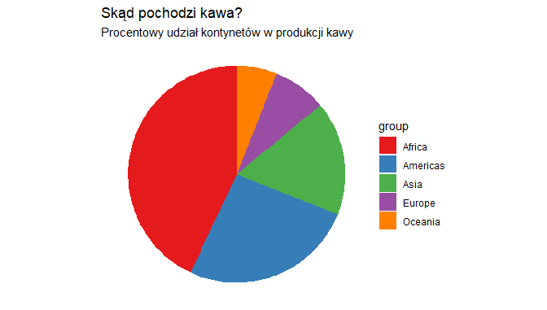

Wykres 1 (wykres kołowy)

Usunięte z wykresu wartości liczbowe sprawiają, że odbiorca, aby oszacować wartość zmiennej, musi sugerować się stosunkiem pola zajmowanego przez daną zmienną w stosunku do pola całego koła.

#### Zadane pytania

1. Uszereguj kontynenty malejąco pod względem ilości wyprodukowanej kawy (1 - najwięcej, 5 - najmniej)
2. Ile procent kawy pochodzi z Azji?
3. Czy w Amerykach jest produkowane więcej niż 25% kawy na świecie?
4. Jak dobrze powyższy wykres kołowy sprawdza się w wizualizacji danych?

#### Pytanie 1

Prawidłowa odpowiedź:

1. Africa
2. Americas
3. Asia
4. Europe
5. Oceania

Z poniższego podsumowania można odczytać, że ankietowani dobrze poradzili sobie z tym zadaniem i zdecydowana ich większość uszeregowała poprawnie kontynenty, a ewentualne rozbieżności pojawiały się w wyznaczaniu 2 i 3 miejsca oraz 4 i 5.

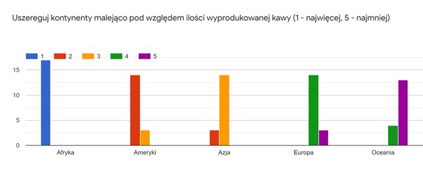

Odpowiedź 1.1

#### Pytanie 2

Poprawna odpowiedź: 17%

Jak widać na poniższym wykresie, ankietowani oszacowywali wartość dla Azji na około 22 procent. O ile na wykresie kołowym stosunkowo łatwo odbiorcy stwierdzali zależności między wartościami, o tyle odczytanie i oszacowywanie dokładnych wartości stanowiło dla nich trudność w wypadku tego rodzaju wykresu.

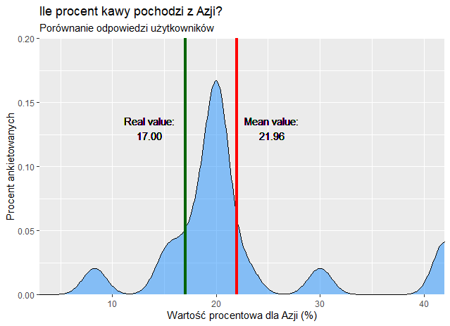

Odpowiedź 1.2

#### Pytanie 3

Poprawna odpowiedź: TAK (26%)

Na pytanie czy w Amerykach jest produkowane więcej niż 25% kawy na świecie tylko 47% użytkowników odpowiedziało poprawnie.

### Wykres słupkowy

Drugi wykres, który został użyty w badaniu, jest wykresem słupkowym ukazującym jaki procent samochodów w danym kraju stanowią samochody elektryczne. Przy tworzeniu wykresu użyłem motywu theme_classic(), który usuwa linie poziome i pionowe na wykresie.

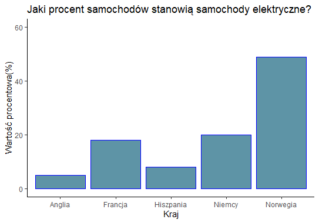

Wykres 2 (wykres słupkowy)

#### Zadane pytania

Ankietowani odpowiadali na trzy pytania:

- Ile procent samochodów w Hiszpanii to samochody elektryczne?
- Pomiędzy którymi krajami jest większa różnica w ilości samochodów elektrycznych (liczba punktów procentowych): Niemcy-Francja, Hiszpania-Anglia, czy różnica jest identyczna
- Jak dobrze powyższy wykres słupkowy sprawdza się w wizualizacji danych?

#### Pytanie 1

Prawidłowa odpowiedź: 8%

Ankietowani dobrze potrafili określić wartość procentową, gdyż średnia ich odpowiedzi wynosi 9.19%.

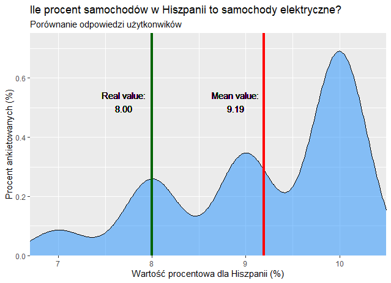

Odpowiedź 2.1

#### Pytanie 2

Na to pytanie tylko 5.9% ankietowanych błędnie stwierdziło, że większa różnica jest pomiędzy Niemcami i Francją, a 59% poprawnie odpowiedziało, że większa różnica jest między Hiszpanią i Anglią.

### Wykres radarowy

Trzeci wykres to wykres radarowy, który przedstawia współczynnik zgonów w zależności od kontynentu. Dodatkowo, współczynnik ten jest pomnożony przez 10, tak aby użytkownik przy odpowiadaniu na pytania używał wartości od 0 do 100, a nie od 0 do 10.

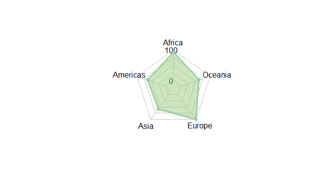

Wykres 3 (wykres radarowy)

#### Zadane pytania

- Uszereguj kontynenty malejąco względem wartości przedstawionej na poniższym wykresie (1 - największa wartość, 5 -najmniejsza)
- Jaką wartość możemy odczytać z powyższego wykresu dla Oceanii?
- Jak dobrze odczytuje się dane z powyższego wykresu?

#### Pytanie 1

Prawidłowa odpowiedź:

1. Europe
2. Africa
3. Americas
4. Oceania
5. Asia

W porównaniu do podobnego zadania z wykresu 1, tutaj użytkownicy dużo gorzej spisali się w uszeregowaniu kontynentów. Łatwo to stwierdzić, gdyż wizualnie przy każdym kontynencie widać przynajmniej po 2 wartości, które ankietowani im przypisywali. Szczególnie to widać, gdy użytkownicy musieli określić dla którego kontynentu występuje najwyższa wartość - tutaj głosy podzieliły się pomiędzy Afryke i Europę.

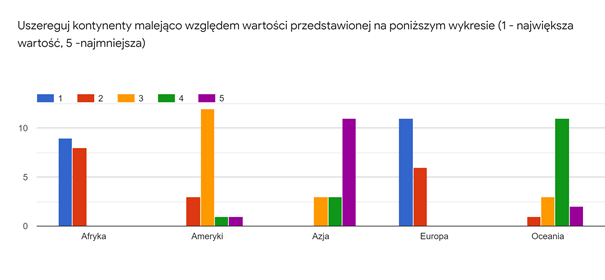

Odpowiedź 3.1

#### Pytanie 2

Prawidłowa odpowiedź: 61.9

Użytkownicy mieli problem z określeniem dokładnej wartości przy wykresie radarowym. Widać to po różnicy pomiędzy średnią wartością wskazywaną przez ankietowanych, a realną wartością.

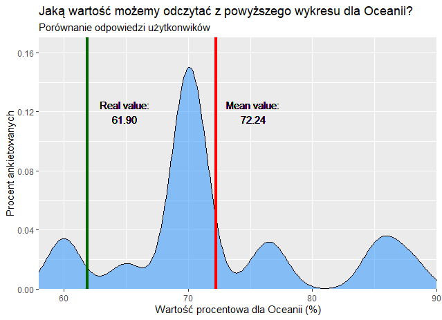

Odpowiedź 3.2

### Wykres lizakowy

Ostatni wykres przedstawia kwotę kieszonkowego pośród 5 znajomych.

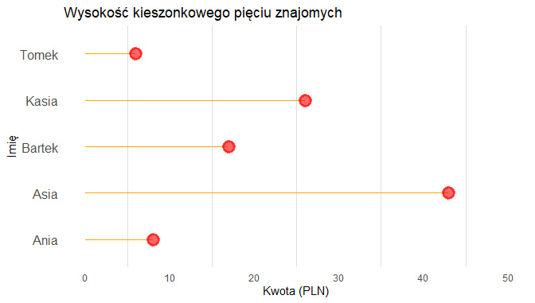

Wykres 4 (wykres lizakowy)

#### Zadane pytania

- Ile kieszonkowego dostaje Bartek?
- Jak dobrze odczytuje się dane z powyższego wykresu słupkowego

#### Pytanie 1

Prawidłowa odpowiedź: 17zł

Wartość wskazywana przez ankietowanych jest stosunkowo bliska wartości prawdziwej, co świadczy o czytelności wykresu lizakowego.

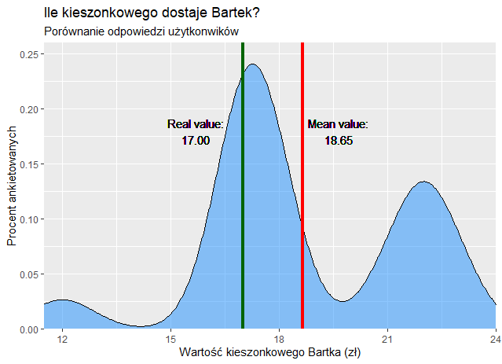

Odpowiedź 4.1

### Wnioski

W każdym z wykresów zadałem pytanie o dokładne podanie wartości dla danej zmiennej. Porównanie rozkładu odpowiedzi ankietowanych pozwala odpowiedzieć na pytanie, który wykres sprawdził się najlepiej. Wyniki porównania znajdują się w tabeli poniżej.

| Chart | 1 | 2 | 3 | 4 |
| --- | --- | --- | --- | --- |
| Mean Value | 21.96 | 9.19 | 72.24 | 18.65 |
| Real Value | 17.00 | 8.00 | 61.90 | 17.00 |
| Relative Error | 29.18 | 14.88 | 16.70 | 9.71 |

Najmniejszy błąd względny między średnią wartością odczytywaną przez użytkowników, a realną wartością jest w przypadku wykresu lizakowego. Tam błąd względny wynosi jedynie 9.71%. Odpowiednio gorzej poradziły sobie wykresy słupkowy, radarowy oraz kołowy, w którym błąd względny wyniósł aż 29.18%.

W ramach kolejnego porównania, dla każdego wykresu ostatnim zadaniem było ocenienie jego czytelności od 1 do 10. Średnie wyniki dla każdego wykresu prezentują się następująco:

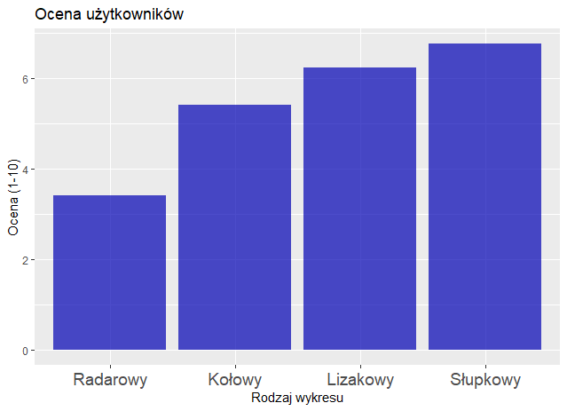

Najlepsze wyniki osiągają wykresy słupkowy i lizakowy, a, tak jak w poprzednim porównaniu, najgorzej zaprezentowały się wykresy kołowy i radarowy.

Dodatkowo, na koniec badania ankietowani wybierali wykres, który według nich najlepiej prezentował dane.

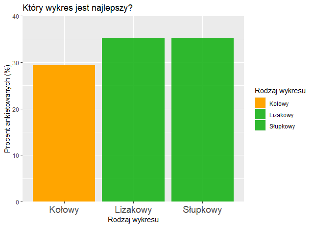

Wybór najlepszego wykresu

Tutaj znowu wygrywają wykresy słupkowy i lizakowy z równą ilością głosów. Zadziwiająco dobrze wypadł też wykres kołowy, na który zagłosowało aż prawie 30% ankietowanych. Wykres radarowy zgodnie z oczekiwaniami nie został wybrany jako najlepszy przez żadnego użytkownika.

### Podsumowanie badania

We wszelkich porównaniach najlepiej poradziły sobie wykresy lizakowy i słupkowy. Potwierdza to ogólnie przyjętą konwencję, że wykres kołowy i radarowy nie są zbyt dobre. Co ciekawe jednak, oceny ankietowanych na temat wykresu kołowego nie odbiegały znacząco od ocen dla wykresów słupkowego i lizakowego. Może to świadczyć o tym, że odbiór wykresu kołowego wśród społeczeństwa, które jest niezwiązane zawodowo z analizą danych, jest pozytywny, natomiast samo odczytywanie danych z tego wykresu jest nieprecyzyjne, co widać bo wysokiej wartości błędu względnego przy odczytywaniu dokładnej wartości. To sprawia, że wykres kołowy jest bardzo dobrym wykresem do manipulacji odbiorcą, gdyż w łatwy sposób można na nim ukryć pewne zależności lub wartości przed użytkownikiem. Natomiast przy rzetelnym i etycznym przedstawianiu danych, warto użyć do wizualizacji wykresu słupkowego lub lizakowego, gdyż są one czytelniejsze i łatwiejsze do odczytania informacji. Powinniśmy jak najmniej używać wykresu radarowego, gdyż nie jest on czytelny i trudno znajduje się na nim zależności między wartościami.